# projectphase1

### Course Project (Phase 1)

For the course project, you will analyze customer churn data from a bank. Customers that “churn” are those that leave the bank. In Phase 1 of the project, you will perform a descriptive analysis of the data and identify variables that may be strong predictors of churn. In Phase 2 of the project, you will build predictive models and assess their performance.

**DO NOT build any models in Phase 1**. Note: A possible exception could be building a Random Forest model to help with variable selection.

Begin by loading packages. You may not need the functionality provided by all of these packages.

Read in the data with the following code:

```r
churn = read_csv("Churn_Modelling.csv")
```

The variables in the dataset are:  
* Row Number - Can be deleted  
* CustomerId - Unique identifier for each customer  
* Surname - Customer’s last name  
* CreditScore - Customer’s credit score (higher is better)  
* Geography - Customer’s country  
* Gender - Customer’s gender  
* Age - Customer’s age  
* Tenure - Number of years that the customer has been with the bank  
* Balance - Customer’s bank balance  
* NumOfProducts - The number of bank products that the customer is using  
* HasCrCard - Indicate whether the customer has (1) a credit card with the bank or (0) not  
* IsActiveMember - Indicates the customer is (1) an active member of the bank or (0) not  
* EstimatedSalary - The estimated salary of the customer  
* Exited - An indicator that shows if the customer closed their account with the bank (1) or (0) not (This is the response variable)

To clean and prepare the data, please complete the following tasks:

- Delete the RowNumber, CustomerId, and Surname columns (NOTE: The MASS package has been loaded so you will need to be careful if you choose to use the select function

```r
churn = churn %>% dplyr::select(-RowNumber, -CustomerId, -Surname)
str(churn)
```

```
tibble [10,000 × 11] (S3: tbl_df/tbl/data.frame)
 $ CreditScore    : num [1:10000] 619 608 502 699 850 645 822 376 501 684 ...
 $ Geography      : chr [1:10000] "France" "Spain" "France" "France" ...
 $ Gender         : chr [1:10000] "Female" "Female" "Female" "Female" ...
 $ Age            : num [1:10000] 42 41 42 39 43 44 50 29 44 27 ...
 $ Tenure         : num [1:10000] 2 1 8 1 2 8 7 4 4 2 ...
 $ Balance        : num [1:10000] 0 83808 159661 0 125511 ...
 $ NumOfProducts  : num [1:10000] 1 1 3 2 1 2 2 4 2 1 ...
 $ HasCrCard      : num [1:10000] 1 0 1 0 1 1 1 1 0 1 ...
 $ IsActiveMember : num [1:10000] 1 1 0 0 1 0 1 0 1 1 ...
 $ EstimatedSalary: num [1:10000] 101349 112543 113932 93827 79084 ...
 $ Exited         : num [1:10000] 1 0 1 0 0 1 0 1 0 0 ...
```

- Convert the Geography, Gender, HasCrCard, IsActiveMember, and Exited columns to factors

```r
#mpg = mpg %>% mutate (trans = as_factor(trans), drv = as_factor(drv), fl = as_factor(fl), class = as_factor(class))
churn = churn %>% mutate (Geography = as_factor(Geography), Gender = as_factor(Gender), HasCrCard = as_factor(HasCrCard), IsActiveMember = as_factor(IsActiveMember), Exited = as_factor(Exited))
str(churn)
```

```
tibble [10,000 × 11] (S3: tbl_df/tbl/data.frame)
 $ CreditScore    : num [1:10000] 619 608 502 699 850 645 822 376 501 684 ...
 $ Geography      : Factor w/ 3 levels "France","Spain",..: 1 2 1 1 2 2 1 3 1 1 ...
 $ Gender         : Factor w/ 2 levels "Female","Male": 1 1 1 1 1 2 2 1 2 2 ...
 $ Age            : num [1:10000] 42 41 42 39 43 44 50 29 44 27 ...
 $ Tenure         : num [1:10000] 2 1 8 1 2 8 7 4 4 2 ...
 $ Balance        : num [1:10000] 0 83808 159661 0 125511 ...
 $ NumOfProducts  : num [1:10000] 1 1 3 2 1 2 2 4 2 1 ...
 $ HasCrCard      : Factor w/ 2 levels "0","1": 2 1 2 1 2 2 2 2 1 2 ...
 $ IsActiveMember : Factor w/ 2 levels "0","1": 2 2 1 1 2 1 2 1 2 2 ...
 $ EstimatedSalary: num [1:10000] 101349 112543 113932 93827 79084 ...
 $ Exited         : Factor w/ 2 levels "0","1": 2 1 2 1 1 2 1 2 1 1 ...
```

- Rename the levels of the HasCrCard, IsActiveMember, and Exited columns from 0 and 1 to No and Yes (You may use more descriptive namings if you prefer)

```r
churn = churn %>% mutate(
  HasCrCard = fct_recode(HasCrCard, "No" = "0", "Yes" = "1") ,
  IsActiveMember = fct_recode(IsActiveMember, "No" = "0", "Yes" = "1") ,
  Exited = fct_recode(Exited, "No" = "0", "Yes" = "1")
)

str(churn)
```

```
tibble [10,000 × 11] (S3: tbl_df/tbl/data.frame)
 $ CreditScore    : num [1:10000] 619 608 502 699 850 645 822 376 501 684 ...
 $ Geography      : Factor w/ 3 levels "France","Spain",..: 1 2 1 1 2 2 1 3 1 1 ...
 $ Gender         : Factor w/ 2 levels "Female","Male": 1 1 1 1 1 2 2 1 2 2 ...
 $ Age            : num [1:10000] 42 41 42 39 43 44 50 29 44 27 ...
 $ Tenure         : num [1:10000] 2 1 8 1 2 8 7 4 4 2 ...
 $ Balance        : num [1:10000] 0 83808 159661 0 125511 ...
 $ NumOfProducts  : num [1:10000] 1 1 3 2 1 2 2 4 2 1 ...
 $ HasCrCard      : Factor w/ 2 levels "No","Yes": 2 1 2 1 2 2 2 2 1 2 ...
 $ IsActiveMember : Factor w/ 2 levels "No","Yes": 2 2 1 1 2 1 2 1 2 2 ...
 $ EstimatedSalary: num [1:10000] 101349 112543 113932 93827 79084 ...
 $ Exited         : Factor w/ 2 levels "No","Yes": 2 1 2 1 1 2 1 2 1 1 ...
```

```r
summary(churn)
```

```
  CreditScore      Geography       Gender          Age            Tenure
 Min.   :350.0   France :5014   Female:4543   Min.   :18.00   Min.   : 0.000
 1st Qu.:584.0   Spain  :2477   Male  :5457   1st Qu.:32.00   1st Qu.: 3.000
 Median :652.0   Germany:2509                 Median :37.00   Median : 5.000
 Mean   :650.5                                Mean   :38.92   Mean   : 5.013
 3rd Qu.:718.0                                3rd Qu.:44.00   3rd Qu.: 7.000
 Max.   :850.0                                Max.   :92.00   Max.   :10.000
    Balance       NumOfProducts  HasCrCard  IsActiveMember EstimatedSalary
 Min.   :     0   Min.   :1.00   No :2945   No :4849       Min.   :    11.58
 1st Qu.:     0   1st Qu.:1.00   Yes:7055   Yes:5151       1st Qu.: 51002.11
 Median : 97199   Median :1.00                             Median :100193.91
 Mean   : 76486   Mean   :1.53                             Mean   :100090.24
 3rd Qu.:127644   3rd Qu.:2.00                             3rd Qu.:149388.25
 Max.   :250898   Max.   :4.00                             Max.   :199992.48
 Exited
 No :7963
 Yes:2037
```

- If there is any missing data, deal with this missingness in an appropriate manner

```r
#didnt notice any missing data
```

- You may also remove any data that you consider to be an outlier

```r
#consider this in phase 2
```

- After cleaning and preparing the data, split the data into training and testing sets (Use a 70/30 training/testing split with a random number seed of 1234)

```r
set.seed(1234)
churn_split = initial_split(churn, prop = 0.7,)
train = training(churn_split)
test = testing(churn_split)
```

Then, perform appropriate analysis on the training set to examine the relationships between each variable and the Exited response variable. Which variables appear likely to be strong predictors of customer churn? What are the possible implications of your findings?

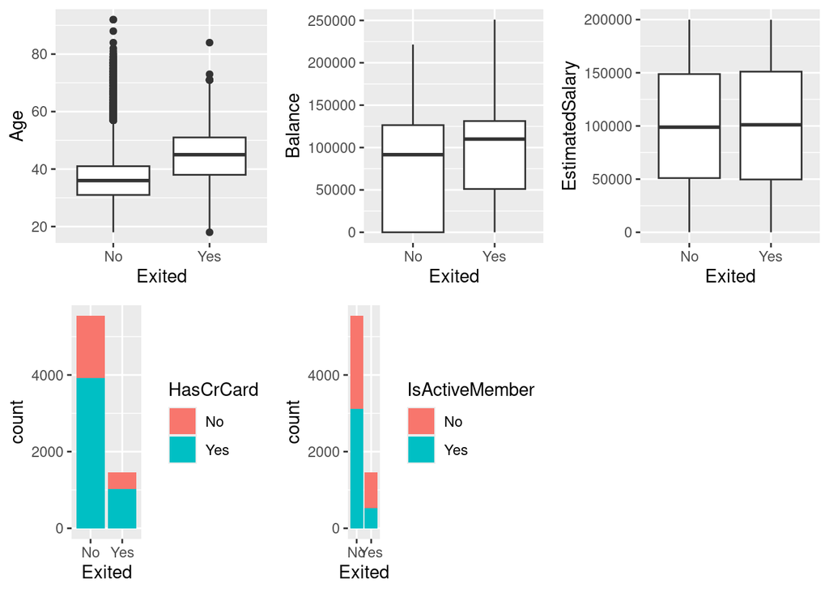

```r
install.packages(c("XML","rpart.plot"))
library(gridExtra)
p1 = ggplot(train, aes(x= Exited, y= Age)) + geom_boxplot()
p4 = ggplot(train, aes(x= Exited, y= Balance)) + geom_boxplot()
p9= ggplot(train, aes(x= Exited, fill = HasCrCard)) + geom_bar()
p10= ggplot(train, aes(x= Exited, fill = IsActiveMember)) + geom_bar()
p6 = ggplot(train, aes(x= Exited, y= EstimatedSalary)) + geom_boxplot()


grid.arrange(p1, p4, p6, p9, p10, nrow = 2)
```

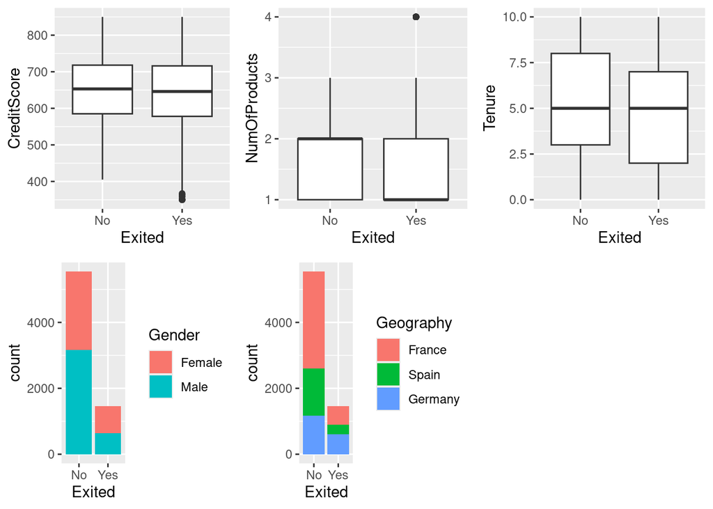

```r
p2 = ggplot(churn, aes(x= Exited, y= CreditScore)) + geom_boxplot()
p5 = ggplot(train, aes(x= Exited, y= NumOfProducts)) + geom_boxplot()
p8= ggplot(train, aes(x=Exited, fill = Gender)) + geom_bar()
p3 = ggplot(train, aes(x=Exited, y= Tenure)) + geom_boxplot()
p7= ggplot(train, aes(x= Exited, fill = Geography)) + geom_bar()

grid.arrange(p2, p5, p3, p8, p7, nrow = 2)
```

**DELIVERABLE** Your deliverable for Phase 1 is a six-slide PowerPoint presentation summarizing your work on this phase and the rendered HTML file as usual. You do not need to deliver (present) the presentation, I only want to see your slides. Your audience for this presentation is non-technical. Do NOT include any R code in your slides. If you are working with a partner, please include their name on the presentation. Only submit one presentation via Canvas per group.